# Practice Worksheet: Animal Weights

Calvin J. Munson

May 7th, 2020

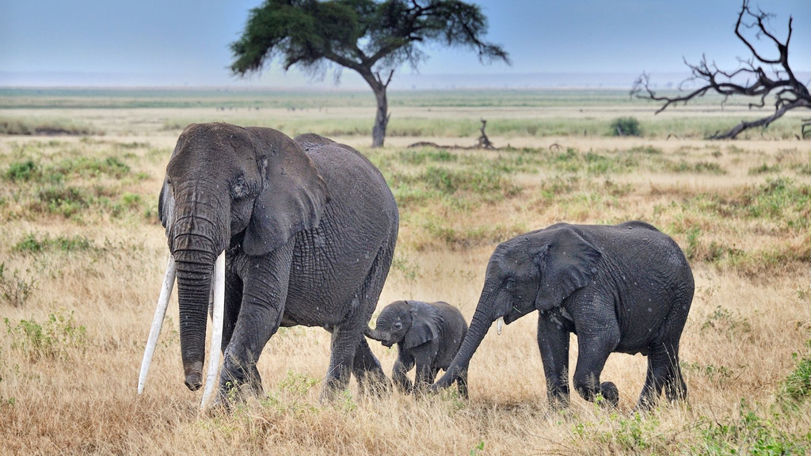

Welcome to this practice worksheet! We will be investigating some trends in the body size of different large mammals. The data for this worksheet is titled “animal_weights.csv”. This document was created in RMarkdown, which is a way to neatly display both text and code together. Great for practice worksheets!

How to navigate the document:

In each section, you will notice two sets of buttons called **code** and **output**. **Code** is a button in the far right of each section. If you click it, the code I use for each section to produce the **output** will be revealed. The **output** is hidden too, though! You can see the **output** of each section (i.e. a graph or a dataframe) but clicking the drop-down arrow next to the word.

I suggest trying to run through each section without looking at the code nor the output. Once you feel you have answered the question or completed the task, you can check and see if your output matches the drop-down output. If it does, then you can also check to see if the code matches up. **If you are stuck on a section, try looking at the output that is generated instead of going right to the code**. Compare the output to the dataframe that you are starting with. What has changed? How can you write code to make those changes? Sometimes seeing the end product may jog your memory! And as always, *Google is your friend*!!! There are certain components of these tasks, particularly with graphing, that I have not brought up in the workshops before, so you will *need* to search around.

If you have any further questions about the data or the code, please do not hesitate to reach out to me at cmunson@ucsc.edu!

Have fun!

## Questions:

#### 1. Set your working directory and load the tidyverse packages from the library

```r
# Set working directory
# Set wd
setwd("~/Desktop/R-DataScience-workshops")

## Call to tidyverse packages
library(tidyverse)
```

#### 2. Read in the .csv file called “animal_weight.csv” and store it in as data object called animal_weights.

After you have read in the file, write code to: a) Look at the header of the data, b) find the number of columns in the data, and c) find the number of rows in the data

```r
animal_weights <- read_csv("~/Desktop/R-DataScience-workshops/practice_worksheets/animal_weights/animal_weight.csv")

## You can also read it in directly from by github repository (requires internet connection)
animal_weights <- read_csv(url("https://raw.githubusercontent.com/calvin-munson/R-DataScience-workshops/master/practice_worksheets/animal_weights/animal_weight.csv"))

# a)
head(animal_weights)
```

**output**

```
## # A tibble: 6 x 6
##   species  sex   age_class individual weight_kg height_m
##   <chr>    <chr> <chr>     <chr>          <dbl>    <dbl>
## 1 Elephant <NA>  Child     A               8000      4
## 2 Elephant <NA>  Child     B               6000      3
## 3 Elephant <NA>  Adult     C              10000      7
## 4 Elephant <NA>  Adult     D               9000      6.5
## 5 Elephant <NA>  Child     E               7000      4
## 6 Elephant <NA>  Child     F               5500      3
```

```r
# b)
ncol(animal_weights)
```

**output**

```
## [1] 6
```

```r
# c)
nrow(animal_weights)
```

**output**

```
## [1] 24
```

#### 3. Identify the unique species and unique age classes present in the dataset

Unique species:

```r
# Unique species:
unique(animal_weights$species)
```

**output**

```
## [1] "Elephant" "Hippo"    "Rhino"
```

Unique age classes:

```r
# Unique age classes:
unique(animal_weights$age_class)
```

**output**

```
## [1] "Child" "Adult"
```

Note: Using the dollar sign to select a column of a dataframe turns that column into a vector of values. You can also use a pipeline to pipe that vector into the function you want to use

```r
animal_weights$species %>% unique()
```

**output**

```
## [1] "Elephant" "Hippo"    "Rhino"
```

#### 4. Write code to calculate the mean weight of each species in the dataset

Hint: group_by() and summarise() are your friends

```r
animal_weights %>%
  group_by(species) %>%
  summarise(mean_weight = mean(weight_kg, na.rm = TRUE))
```

**output**

```
## # A tibble: 3 x 2
##   species  mean_weight
##   <chr>          <dbl>
## 1 Elephant       7875
## 2 Hippo          1888.
## 3 Rhino          1781.
```

#### 5. Calculate the same average weight, but this time for each species/age class combination in the dataset (for instance, what does the average elephant child weight? Elephant adult? Hippo child? etc)

```r
animal_weights %>%
  group_by(species, age_class) %>%
  summarise(mean_weight = mean(weight_kg, na.rm = TRUE))
```

**output**

```
## # A tibble: 6 x 3
## # Groups:   species [3]
##   species  age_class mean_weight
##   <chr>    <chr>           <dbl>
## 1 Elephant Adult           9125
## 2 Elephant Child           6625
## 3 Hippo    Adult           2300
## 4 Hippo    Child           1475
## 5 Rhino    Adult           2225
## 6 Rhino    Child           1338.
```

#### 6. Next, calculate both mean weight AND mean height in the same data frame for each species/age class combination

```r
animal_weights %>%
  group_by(species, age_class) %>%
  summarise(mean_weight = mean(weight_kg, na.rm = TRUE),
            mean_height = mean(height_m, na.rm = TRUE))
```

**output**

```
## # A tibble: 6 x 4
## # Groups:   species [3]
##   species  age_class mean_weight mean_height
##   <chr>    <chr>           <dbl>       <dbl>
## 1 Elephant Adult           9125         6.6
## 2 Elephant Child           6625         3.5
## 3 Hippo    Adult           2300         1.48
## 4 Hippo    Child           1475         0.9
## 5 Rhino    Adult           2225         1.62
## 6 Rhino    Child           1338.        1.12
```

#### 7. You may have noticed that there is also a column for the sex of the animal, but that the data only exists for the Hippos in our dataset. Create a new dataframe called hippo_stats, which a) only includes data from Hippos, and b) has the mean weight and height for each species, sex, and age combination in the dataset.

```r
hippo_stats <- animal_weights %>%
  # a) Filter the original dataframe to only include Hippos
  filter(species == "Hippo") %>%
  # b) Group by all 3 columns of interest and summarise
  group_by(species, sex, age_class) %>%
  summarise(mean_weight = mean(weight_kg, na.rm = TRUE),
            mean_height = mean(height_m, na.rm = TRUE))

hippo_stats
```

**output**

```
## # A tibble: 4 x 5
## # Groups:   species, sex [2]
##   species sex    age_class mean_weight mean_height
##   <chr>   <chr>  <chr>           <dbl>       <dbl>
## 1 Hippo   Female Adult            1500        1.4
## 2 Hippo   Female Child            1200        0.8
## 3 Hippo   Male   Adult            3100        1.55
## 4 Hippo   Male   Child            1750        1
```

#### 8. Calculate Body Mass Index (BMI) for each individual animal

In humans, BMI is calculated as:

$$BMI = kg/m^{2}$$

Where BMI is body mass index, kg is mass in kilograms, and m is height in meters.

Taking the original dataframe, create a new column that contains a calculated BMI for each individual animal (this is obviously totally meaningless in terms of actual data on these species!)

Hint: mutate() is your friend! Also, if you are stuck on how to square a value in R, check out our even better friend, Google!

```r
animal_weights %>%
  mutate(BMI = weight_kg/height_m^2)
```

**output**

```
## # A tibble: 24 x 7
##    species  sex    age_class individual weight_kg height_m   BMI
##    <chr>    <chr>  <chr>     <chr>          <dbl>    <dbl> <dbl>
##  1 Elephant <NA>   Child     A               8000      4    500
##  2 Elephant <NA>   Child     B               6000      3    667.
##  3 Elephant <NA>   Adult     C              10000      7    204.
##  4 Elephant <NA>   Adult     D               9000      6.5  213.
##  5 Elephant <NA>   Child     E               7000      4    438.
##  6 Elephant <NA>   Child     F               5500      3    611.
##  7 Elephant <NA>   Adult     G               9000      6.4  220.
##  8 Elephant <NA>   Adult     H               8500      6.5  201.
##  9 Hippo    Female Adult     A               1400      1.4  714.
## 10 Hippo    Female Adult     B               1600      1.4  816.
## # … with 14 more rows
```

#### 9. Using ggplot, create a set of boxplots showing the distribution of weights for each species

Hint: Think about what value you want on which axis

```r
animal_weights %>%
  ggplot(aes(x = species, y = weight_kg)) +
  geom_boxplot()
```

**plot**

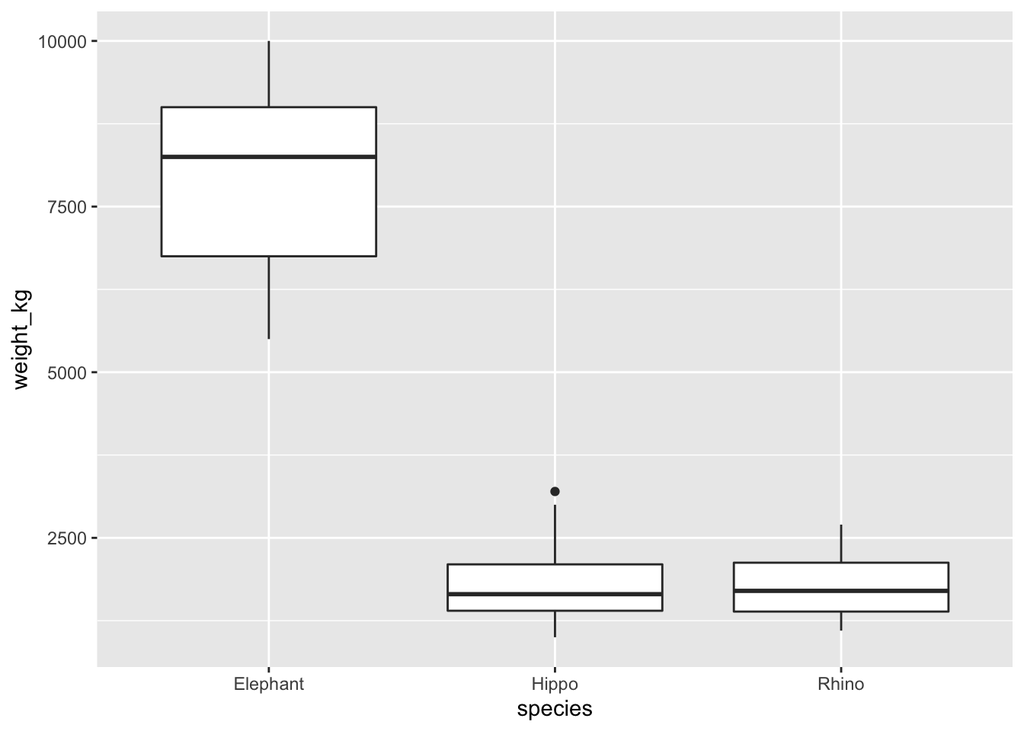

#### 10. Create a more detailed boxplot, this time including the fill of the boxplot as the age class of the species

Additionally, change a few of the features of the plot:

1. Add neat x and y axis labels
2. Add a plot title
3. Change the y-axis limits to include 0 as a minimum

Hint: Again, use Google if you’re stuck on how to change these features. The website Stack Overflow is a great place to go.

```r
animal_weights %>%
  ggplot(aes(x = species, y = weight_kg, fill = age_class)) +
  geom_boxplot() +
  # a)
  labs(x = "Species", y = "Weight (kilograms)", fill = "Age class") +
  # b)
  ggtitle("Weight distributions for each species and age class") +
  # c)
  ylim(0,11000)
```

**plot**

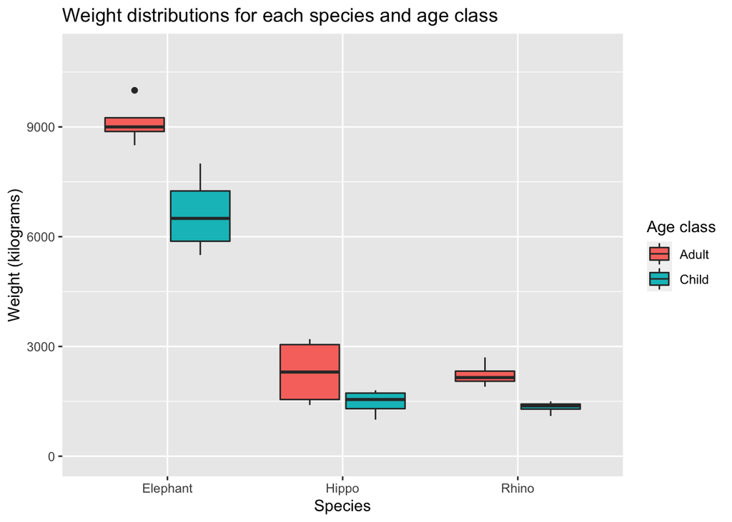

Note: If you assigned a column to the “fill” aesthetic (same thing goes for other aesthetics, like “color” or “shape”), you can also specify a new label for it as I did in the labs() arguement. That label will show up over the legend.

I hope this worksheet was helpful! Please feel free to email me with any questions.

-Calvin